# IODS course project

Laura Häkkinen

# Introduction to Open Data Science - Course Project

# Chapter 1: About the project

*Introduction to Open Data Science course, Autumn 2023*

```r
# This is a so-called "R chunk" where you can write R code.

date()
```

```
## [1] "Tue Dec  5 00:30:36 2023"
```

## My experience

I heard about the course through my doctoral school’s e-mail list, took a closer look at the contents of the course and found the course to be beneficial to my studies and current and future work.

I just finished watching the webinars and reading the recommended chapters for this week from R for Health Data Science and the MABS4IODS. I am excited to learn about GitHub and more about good practices in R and R Markdown, even though I have used R for a year already. My learning of R thus far has been task orientated and I realize that it is good to recap the basics. I especially want and expect to learn about GitHub, which I have not used before.

## New things I learned

- I learned new things from the Excercise set 1. New packages or functions for me were:
  - lubridate (package) to handle dates
  - **bind_rows()** to add new rows to tibble from new tibble
  - **fct_relevel()** to change factor level order e.g. in
  - → mutate(income = **fct_relevel**(income, “Low”, “Lower-Middle”, “Upper-Middle”, “High”))
  - **starts_with()** to use e.g. with select to get all columns that start with a certain string as in e.g.
  - → **select**(starts_with(“deaths”))
  - **matches()** to use e.g. with pivot_longer to operate on columns that match a certain string, and can also take operators like AND (&) or OR (|) as in e.g.
  - → gbd_wide %>% pivot_longer(**matches**(“Female**|**Male”), names_to = “sex_year”, values_to = “deaths_millions”)
- Something I knew, but rarely use automatically (without googleing) and hope to use more and more confidently for now on were operators or functions:
  - **%in%** (operator?) for e.g. in the following code
  - → filter(cause **%in%** c(“Communicable diseases”, “Non-communicable diseases”)
  - **mutate()** to modify tibble for e.g. by adding columns, as in the following codes
  - → **mutate**(above_threshold = if_else(measurement > 3, “Above three”, “Below three”))
  - → typesdata %>% **mutate**(plot_label = paste(id, “was last measured at”, date, “, and the value was”, measurement))
  - → pastedata %>% **mutate**(date = paste(day, month, year, sep = “-”))
- Although I use **group_by()** command often, it is good to recap
  - → gbd2017 %>% **group_by**(cause, sex) %>% summarise(deaths_per_group = sum(deaths_millions))
- I also realized, I use data frame more often than I use **tibble** and it might be good to change this

## Thoughts about plotting with ggplot2

- I didn’t realize that it’s possible to do *filtering inside ggplot*, as in:
  - → + facet_wrap(~pop **> 50000000**)
- Or *do transformations*, e.g. divide values by 1000 as in:
  - → ggplot(aes(x = gdpPercap**/1000**, y = lifeExp, colour = continent))
- I have not used the **size** argument in ggplot aes() before to form a *bubble plot* as in:
  - rarr; ggplot(aes(x = gdpPercap/1000, y = lifeExp, **size** = pop))
- Two things to remember from the following code:
  - 1. that I can use *fct_reorder()* to reorder according to e.g. value *within ggplot*, and
  - 2. when to use color and fill *arguments within geom() rather than aes()*
  - → gapdata2007 %>% filter(continent == “Europe”) %>% ggplot(aes(x = **fct_reorder**(country, lifeExp), y = lifeExp)) + geom_col(**color = “deepskyblue”, fill = NA**) + coord_flip()
- I should start using more often the **Multiple geoms** property of ggplot for *overlapping ploting* as in e.g.
  - → geom_boxplot() + geom_jitter()
- And that I can have both *shared* aes() for the plottings as well as *separate* aes(), as in:
  - → gapdata2007 %>% ggplot(aes(**x** = continent, **y** = lifeExp)) + geom_boxplot() + geom_jitter(aes(**colour** = continent))

# Chapter 2: Linear regression

```r
date()
```

```
## [1] "Tue Dec  5 00:30:37 2023"
```

*This week we worked with linear regression. we learned how to do linear regression model with lm(), how to interpret the test statistics of linear model, and how to do graphical diagnostics for the data to be able to decide if the assumptions for linear regeression are met*

## The students2014 dataset

Data is **modified** results from an international survey of Approaches to Learning, that was collected between 3.12.2014 - 10.1.2015 by Kimmo Vehkalahti. **Original data** can be found from: http://www.helsinki.fi/~kvehkala/JYTmooc/JYTOPKYS3-data.txt

More information of the data can be found from here: https://www.mv.helsinki.fi/home/kvehkala/JYTmooc/JYTOPKYS3-meta.txt

The following **modifications** to the data was done by Laura Häkkinen on 07.11.2023: Zero values for variable “points” are NA and were removed from the data to include 166 observations, while the original data had 183 observations. Only variables “age”, “points”, and “gender” were taken from the original data without modificatios, while “attitude” is “Attitude” from the original data divided by 10 to scale as a mean value of ten questions, and “deep”, “surf”, and “stra” were calculated as **mean values** for multiple questions in these categories

The modified data here contains results for a set of questions which are classified to 3 categories: - deep questions (**deep**) - surface questions (**surf**) - strategic questions (**stra**)

as well as: - global attitude toward statistics (**attitude**) - exam points (**points**) - age of the person (in years) (**age**) derived from the date of birth - gender of the person (**gender**) given as M (Male), F (Female)

```r
dataset <- read.csv2("\\\\ad.helsinki.fi\\home\\l\\lehakkin\\Desktop\\KURSSIT\\Open_Data_Science\\IODS-project\\data\\learning2014.csv")
str(dataset)
```

```
## 'data.frame':    166 obs. of  7 variables:
##  $ age     : int  53 55 49 53 49 38 50 37 37 42 ...
##  $ attitude: num  3.7 3.1 2.5 3.5 3.7 3.8 3.5 2.9 3.8 2.1 ...
##  $ points  : int  25 12 24 10 22 21 21 31 24 26 ...
##  $ gender  : chr  "F" "M" "F" "M" ...
##  $ deep    : num  3.58 2.92 3.5 3.5 3.67 ...
##  $ surf    : num  2.58 3.17 2.25 2.25 2.83 ...
##  $ stra    : num  3.38 2.75 3.62 3.12 3.62 ...
```

```r
# put gender as the first varialble
dataset <- dataset[, c(4,1,2,3,5,6,7)]
```

## Graphical overview of the dataset

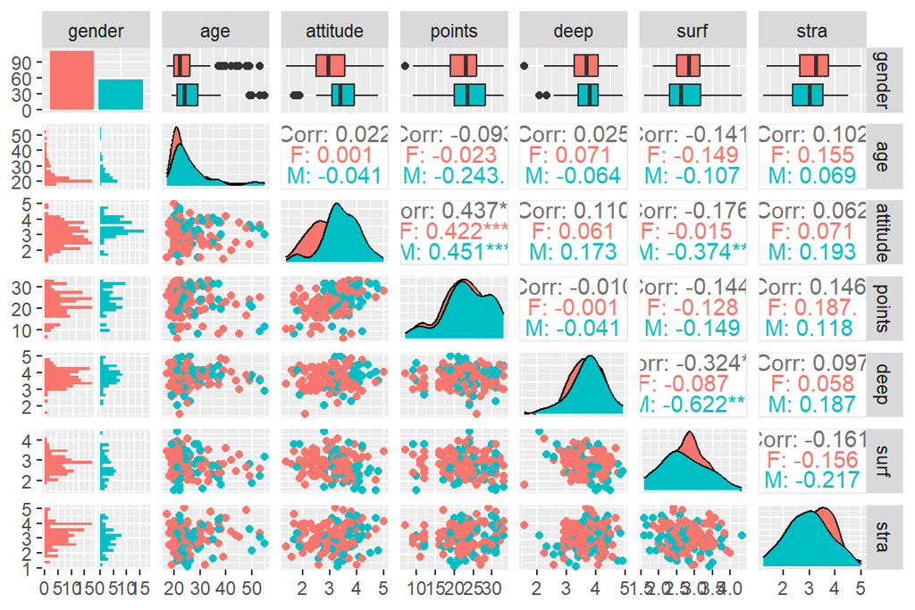

```r
# access the GGally and ggplot2 libraries
library(GGally)
library(ggplot2)

# create plot matrix with ggpairs()
p <- ggpairs(dataset, mapping = aes(col = gender), lower = list(combo = wrap("facethist", bins = 20)))

# draw the plot
p
```

### Distributions of the data

Distributions look otherwise ok (close to normal) except for: - age, which is right skewed - points, which seem to have 2-3 peaks - deep for M seems to be a bit left skewed - surf for M a bit right skewed

### Correlations

Significantly correlating variables are - attitude and points: strong positive correlation for All (0.437), F, and M - surf and attitude: negative correlation for All (-0.176), but only significant for M - surf and deep: negative correlation for All (-0.324), but only significant for M, for which the correlation is strong (-0.622) - surf and stra: negative correlation found when both genders included, but individually within F and M no significant correlation

### Other comments

- there are more females than to males
- age median value is ~20, but a bit higher for M
- attitude median values are higher for M
- there seems to be up to 3 peaks for points with values approx. at 10, 20 and 30
- surf and stra median values differ between M and F

## Regression model

We will make a regression model for the data so that “points” is the dependent variable. Since attitude had the highest correlations with exam points, let’s include it as an explanatory variables.

Stra *marginally* correlates with points, so let’s add that as well

```r
m <- lm(points ~ attitude + stra + surf, data = dataset)
summary(m)
```

```
##
## Call:
## lm(formula = points ~ attitude + stra + surf, data = dataset)
##
## Residuals:
##      Min       1Q   Median       3Q      Max
## -17.1550  -3.4346   0.5156   3.6401  10.8952
##
## Coefficients:
##             Estimate Std. Error t value Pr(>|t|)
## (Intercept)  11.0171     3.6837   2.991  0.00322 **
## attitude      3.3952     0.5741   5.913 1.93e-08 ***
## stra          0.8531     0.5416   1.575  0.11716
## surf         -0.5861     0.8014  -0.731  0.46563
## ---
## Signif. codes:  0 '***' 0.001 '**' 0.01 '*' 0.05 '.' 0.1 ' ' 1
##
## Residual standard error: 5.296 on 162 degrees of freedom
## Multiple R-squared:  0.2074, Adjusted R-squared:  0.1927
## F-statistic: 14.13 on 3 and 162 DF,  p-value: 3.156e-08
```

### Model 1 interpretation

The F-statistic for the whole model gives a significant p value (3.156e-08), meaning that there is strong evidence that not all three coefficients are zero, but the stra and surf explanatory variables do not have a statistically significant relationship with the target variable (points), so I will remove them and only leave attitude, which is highly significant with p values smaller than 0.001 (1.93e-08). The multiple R2 value, i.e. square of the multiple correlation coefficient, for the model is 0.2074 meaning that the model explains ~21% of the variation in the data.

### Running a new model

```r
m2 <- lm(points ~ attitude, data = dataset)
summary(m2)
```

```
##
## Call:
## lm(formula = points ~ attitude, data = dataset)
##
## Residuals:
##      Min       1Q   Median       3Q      Max
## -16.9763  -3.2119   0.4339   4.1534  10.6645
##
## Coefficients:
##             Estimate Std. Error t value Pr(>|t|)
## (Intercept)  11.6372     1.8303   6.358 1.95e-09 ***
## attitude      3.5255     0.5674   6.214 4.12e-09 ***
## ---
## Signif. codes:  0 '***' 0.001 '**' 0.01 '*' 0.05 '.' 0.1 ' ' 1
##
## Residual standard error: 5.32 on 164 degrees of freedom
## Multiple R-squared:  0.1906, Adjusted R-squared:  0.1856
## F-statistic: 38.61 on 1 and 164 DF,  p-value: 4.119e-09
```

### Model 2 interpretation

Now only one explanatory variable, attitude, which is significant. The relationship between attitude and points is positive, meaning that a higher value in attitude gives a higher value in points. The estimate value 3.5255 means that the mean of points variable changes this much given a one-unit shift in the attitude value (while holding other variables in the model constant). Effect could be written as: points = 11.6372 + 3.5255**attitude

Model multiple R2 value is 0.1906 meaning that the model explains ~19% (or the variation in additude explains ~19%) of the variation in the points

The F-statistic for the whole model gives a significant p value (4.119e-09)